**MIT License (click to expand)**

[output not shown]

# Introduction

A simple neural network demo site: https://playground.tensorflow.org/

# Supervised Classification of MNIST (Handwritten Digits)

The goal of this hands-on exercise is to help you understand the overall workflow of building a deep learning model.

## Goal: Classify handwritten digits from "0" to "9"

The MNIST database (Modified National Institute of Standards and Technology database) is an image dataset of handwritten digits from "0" to "9". It is often used as a practice dataset in machine learning and deep learning. Many Python libraries also provide it as a ready-to-use sample dataset.

Sample images from the MNIST test dataset:

[figure not shown]

MNIST database (Apr. 12, 2023, 00:15 UTC). In Wikipedia: The Free Encyclopedia. Retrieved from https://en.wikipedia.org/wiki/MNIST_database

In this notebook, we will use a deep learning model to automatically classify handwritten digit images from "0" to "9".

Available information (input data type): **handwritten digit images** from "0" to "9"  
Target result (output data type): classification into numeric labels from "0" to "9"

One useful feature of this dataset is that several standard preprocessing steps have already been applied, so we can use it easily as real data:

- The size of the handwritten digits is standardized.
- Each handwritten digit is placed at the center of the image.
- The dataset is already split into training data and test data.
  - Training: 60,000 samples, Test: 10,000 samples
- Ground-truth labels are already assigned.

[Original paper](https://ieeexplore.ieee.org/document/726791): Y. LeCun, L. Bottou, Y. Bengio and P. Haffner, "Gradient-based learning applied to document recognition," in *Proceedings of the IEEE*, vol. 86, no. 11, pp. 2278-2324, Nov. 1998, doi: 10.1109/5.726791.

## Check GPU availability and the TensorFlow version

```python
!nvidia-smi
```

```
Tue May 12 09:39:05 2026
+-----------------------------------------------------------------------------------------+
| NVIDIA-SMI 580.82.07              Driver Version: 580.82.07      CUDA Version: 13.0     |
+-----------------------------------------+------------------------+----------------------+
| GPU  Name                 Persistence-M | Bus-Id          Disp.A | Volatile Uncorr. ECC |
| Fan  Temp   Perf          Pwr:Usage/Cap |           Memory-Usage | GPU-Util  Compute M. |
|                                         |                        |               MIG M. |
|=========================================+========================+======================|
|   0  Tesla T4                       Off |   00000000:00:04.0 Off |                    0 |
| N/A   60C    P8             29W /   70W |       0MiB /  15360MiB |      0%      Default |
|                                         |                        |                  N/A |
+-----------------------------------------+------------------------+----------------------+

+-----------------------------------------------------------------------------------------+
| Processes:                                                                              |
|  GPU   GI   CI              PID   Type   Process name                        GPU Memory |
|        ID   ID                                                               Usage      |
|=========================================================================================|
|  No running processes found                                                             |
+-----------------------------------------------------------------------------------------+
```

```python
import tensorflow as tf
import sklearn
import os

print('TensorFlow version:', tf.__version__)
print('scikit-learn version:', sklearn.__version__)

restart_flag = False

if tf.__version__ != '2.20.0':
    !pip install -q --upgrade tensorflow==2.20.0
    print('TensorFlow version:', tf.__version__)
    restart_flag = True

if sklearn.__version__ != '1.6.1':
    !pip install -q --upgrade scikit-learn==1.6.1
    print('scikit-learn version:', sklearn.__version__)
    restart_flag = True

# Run the following block only when a library version has changed.
if restart_flag:
    print("The runtime will restart automatically because a library version was changed.")
    print("In Colab, you may see a warning in the lower-left corner saying it crashed for an unknown reason.")
    print("You can ignore that warning and continue with the next code cells.")
    # Intentionally trigger a restart.
    get_ipython().kernel.do_shutdown(restart=True)
```

```
TensorFlow version: 2.20.0
scikit-learn version: 1.6.1
```

### Import packages

```python
import os  # os: standard library for OS-related tasks such as environment variables and folder creation
import datetime  # datetime: standard library for date and time data
import random  # random: standard library for pseudo-random number generation
import numpy as np  # numpy: a library for numerical computing

import pandas as pd  # pandas: a library for tabular data processing
pd.options.display.precision = 4  # set the number of displayed decimal places

from IPython.display import display  # display data more clearly than print() in Colab and similar environments
import matplotlib.pylab as plt  # matplotlib: a library for plotting

import seaborn as sns  # seaborn: a library for plotting
from sklearn.metrics import classification_report  # used here to output Precision, Recall, and F1-score
# tensorboard: dashboard support for the deep learning library TensorFlow
%load_ext tensorboard
import tensorflow as tf  # TensorFlow: a deep learning library
```

### Fix the random seed for pseudo-random number generators

- This fixes the pseudo-random number sequences generated and used in the code below.
- A random seed is the value used to initialize a pseudo-random number generator.
- If you do not set it explicitly, it is usually initialized from the current time or a similar value.
- In this notebook, we fix the random seed to improve reproducibility, so anyone running the notebook can get the same pseudo-random sequence.

Note: In Colab, perfect reproducibility may still be difficult because the assigned CPU/GPU and library versions can differ.

```python
def set_seed(seed=123):
    # Fix the hash seed.
    os.environ["PYTHONHASHSEED"] = str(seed)
    # Make TensorFlow operations deterministic.
    os.environ['TF_DETERMINISTIC_OPS'] = 'true'
    # Make cuDNN operations deterministic.
    os.environ['TF_CUDNN_DETERMINISTIC'] = 'true'
    # Fix the seed for Python's standard random library.
    random.seed(seed)
    # Fix the seed for NumPy.
    np.random.seed(seed)
    # Fix the seed for TensorFlow.
    tf.random.set_seed(seed)

set_seed(42)
```

## tensorflow / keras

### Load and split the dataset

```python
# Load the MNIST dataset from the TensorFlow library instead of the original website.
# This is easier because the data format is already prepared for use.

(x_learn, y_learn), (x_test, y_test) = tf.keras.datasets.mnist.load_data()

# Split the data used for model training into training data and validation data.
x_train = x_learn[0:int(len(x_learn) * 0.7), :]
y_train = y_learn[0:int(len(y_learn) * 0.7)]

x_valid = x_learn[int(len(x_learn) * 0.7):len(x_learn), :]
y_valid = y_learn[int(len(y_learn) * 0.7):len(y_learn)]

# Check the number of samples in each dataset.

# Training data
print("x_train : ", x_train.shape)
print("y_train : ", y_train.shape)

# Validation data
print("x_valid : ", x_valid.shape)
print("y_valid : ", y_valid.shape)

# Test data
print("x_test : ", x_test.shape)
print("y_test : ", y_test.shape)
```

```
x_train :  (42000, 28, 28)
y_train :  (42000,)
x_valid :  (18000, 28, 28)
y_valid :  (18000,)
x_test :  (10000, 28, 28)
y_test :  (10000,)
```

About the role of each dataset:

| Purpose | Description |
| --- | --- |
| Training dataset | Data used to train the model |
| Validation dataset Evaluation dataset | Data used during training to check model accuracy. It is recorded at each training iteration to evaluate whether performance on unseen data is improving (that is, whether the model is generalizing). |
| Test dataset | Data used to test the accuracy of the final model. |

What is the difference between a validation dataset and a test dataset in machine learning / deep learning?

- The validation dataset is used as a reference when humans adjust hyperparameters.
- The test dataset is used only to evaluate the final model after hyperparameter tuning and training are finished.

By preparing a test dataset that is **never used** for model training or parameter tuning, we can simulate how the model will perform on unseen data. If we use a dataset that was already used for training or hyperparameter tuning to evaluate the final model, the result will usually look better than real-world performance.

### Visualize part of the dataset

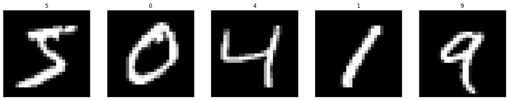

```python
# Visualize five samples from the dataset

fig = plt.figure(figsize=(20,20))
for i in range(5):
    ax = fig.add_subplot(1, 5, i+1, xticks=[], yticks=[])
    ax.imshow(x_train[i].reshape(28,28), cmap='gray')
    ax.set_title(str(y_train[i]))
plt.show()
```

### Normalize the dataset (Min-Max Normalization)

The images in this dataset are grayscale images made of integer values from 0 to 255.

Normalization (Min-Max Normalization) is a method that scales values to the range from 0 to 1 when the minimum and maximum are known. In image processing, it is often used to reduce training cost.

Note: Min-Max Normalization is strongly affected by outliers. If the maximum and minimum are not fixed, or if outliers are present, other methods are often used.

```python
print("Before Min-Max Normalization")
print("x_train min", x_train.min())
print("x_train max", x_train.max())

x_train = (x_train - np.min(x_train)) / (np.max(x_train) - np.min(x_train))
x_valid = (x_valid - np.min(x_valid)) / (np.max(x_valid) - np.min(x_valid))
x_test = (x_test - np.min(x_test)) / (np.max(x_test) - np.min(x_test))

print("After Min-Max Normalization")
print("x_train min", x_train.min())
print("x_train max", x_train.max())
```

```
Before Min-Max Normalization
x_train min 0
x_train max 255
After Min-Max Normalization
x_train min 0.0
x_train max 1.0
```

### One-hot encoding for label data

```python
# One-hot encoding for label data

print("Before one-hot encoding")
print("y_train[0]:", y_train[0])
print("y_valid[0]:", y_valid[0])
print("y_test[0] :", y_test[0])
print()

y_train_onehot = tf.keras.utils.to_categorical(y_train)
y_valid_onehot = tf.keras.utils.to_categorical(y_valid)
y_test_onehot = tf.keras.utils.to_categorical(y_test)

print("After one-hot encoding")
print("y_train_onehot[0]:", y_train_onehot[0])
print("y_valid_onehot[0]:", y_valid_onehot[0])
print("y_test_onehot[0] :", y_test_onehot[0])
```

```
Before one-hot encoding
y_train[0]: 5
y_valid[0]: 1
y_test[0] : 7

After one-hot encoding
y_train_onehot[0]: [0. 0. 0. 0. 0. 1. 0. 0. 0. 0.]
y_valid_onehot[0]: [0. 1. 0. 0. 0. 0. 0. 0. 0. 0.]
y_test_onehot[0] : [0. 0. 0. 0. 0. 0. 0. 1. 0. 0.]
```

### Define the model

```python
# Define the model

# Input layer
inputs_images = tf.keras.layers.Input(shape=(28, 28, 1), name='input')

# Flatten layer
# (None, 28, 28, 1) -> (None, 784)
x = tf.keras.layers.Flatten()(inputs_images)

# Dense layers
# (None, 784) -> (None, 512)
x = tf.keras.layers.Dense(units=512, activation='relu', name='fc_1')(x)
# (None, 512) -> (None, 256)
x = tf.keras.layers.Dense(units=256, activation='relu', name='fc_2')(x)
# (None, 256) -> (None, 128)
x = tf.keras.layers.Dense(units=128, activation='relu', name='fc_3')(x)
# (None, 128) -> (None, 10)
outputs = tf.keras.layers.Dense(units=10, activation='softmax')(x)

model = tf.keras.Model(inputs=inputs_images, outputs=outputs, name='mnist_model')

# Compile the model (set the optimization algorithm, loss function, evaluation metric, etc.).
# You will learn about the loss function in Section 2.6.
model.compile(optimizer='adam',
              loss='categorical_crossentropy',
              metrics=['accuracy'])

# Print the model structure as text.
model.summary()
```

```
Model: "mnist_model"
```

```
┏━━━━━━━━━━━━━━━━━━━━━━━━━━━━━━━━━┳━━━━━━━━━━━━━━━━━━━━━━━━┳━━━━━━━━━━━━━━━┓
┃ Layer (type)                    ┃ Output Shape           ┃       Param # ┃
┡━━━━━━━━━━━━━━━━━━━━━━━━━━━━━━━━━╇━━━━━━━━━━━━━━━━━━━━━━━━╇━━━━━━━━━━━━━━━┩
│ input (InputLayer)              │ (None, 28, 28, 1)      │             0 │
├─────────────────────────────────┼────────────────────────┼───────────────┤
│ flatten (Flatten)               │ (None, 784)            │             0 │
├─────────────────────────────────┼────────────────────────┼───────────────┤
│ fc_1 (Dense)                    │ (None, 512)            │       401,920 │
├─────────────────────────────────┼────────────────────────┼───────────────┤
│ fc_2 (Dense)                    │ (None, 256)            │       131,328 │
├─────────────────────────────────┼────────────────────────┼───────────────┤
│ fc_3 (Dense)                    │ (None, 128)            │        32,896 │
├─────────────────────────────────┼────────────────────────┼───────────────┤
│ dense (Dense)                   │ (None, 10)             │         1,290 │
└─────────────────────────────────┴────────────────────────┴───────────────┘
```

```
 Total params: 567,434 (2.16 MB)
```

```
 Trainable params: 567,434 (2.16 MB)
```

```
 Non-trainable params: 0 (0.00 B)
```

### Run inference with the untrained model

```
1/1 ━━━━━━━━━━━━━━━━━━━━ 0s 386ms/step
```

|  | 0 | 1 | 2 | 3 | 4 | 5 | 6 | 7 | 8 | 9 |
| --- | --- | --- | --- | --- | --- | --- | --- | --- | --- | --- |
| y_test_pred (i=0) | 0.104 | 0.083 | 0.1029 | 0.0777 | 0.1115 | 0.0993 | 0.0846 | 0.0952 | 0.1273 | 0.1144 |

```
Label with the highest predicted probability (i=0):  8

y_test_true (i=0):  7
x_test (i=0):
```

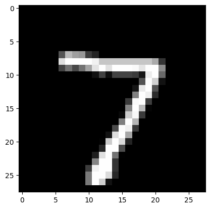

```python
# Visualize the first sample in the test data.
for i in [0]:
    y_true = y_test[i]
    y_pred = model.predict(x_test[i].reshape(1, 28, 28))[0]
    display(pd.DataFrame(columns=range(10), index=[f'y_test_pred (i={str(i)})'], data=[y_pred.tolist()]))
    print("Label with the highest predicted probability", "(i=" + str(i) + "): ", tf.math.argmax(y_pred).numpy(), "\n")

    print("y_test_true", "(i=" + str(i) + "): ", y_true)
    print("x_test", "(i=" + str(i) + "): ")

    plt.imshow(x_test[i], cmap='gray')
    plt.show()
    print("-------------------------------------------------------------\n")
```

You can see that the prediction is incorrect. Now let us train the model.

### Train the model

```python
# Prepare to create a log file during training.
callbacks = []
callbacks.append(tf.keras.callbacks.CSVLogger('training_log.csv'))

# Prepare TensorBoard output.
os.makedirs('/contents/logs/fit/', exist_ok=True)  # create the folder
log_dir = "logs/fit/" + datetime.datetime.now().strftime("%Y%m%d-%H%M%S")
tensorboard_callback = tf.keras.callbacks.TensorBoard(log_dir=log_dir, histogram_freq=1)

callbacks.append(tensorboard_callback)

# Train the model (about 1 minute on GPU).
history = model.fit(x_train, y_train_onehot,
                    batch_size=128,
                    epochs=20,
                    verbose=1,
                    validation_data=(x_valid, y_valid_onehot),
                    callbacks=callbacks
                    )

model_save_path = 'trained_model_mnist.keras'
model.save(model_save_path)
```

```
329/329 ━━━━━━━━━━━━━━━━━━━━ 10s 9ms/step - accuracy: 0.9211 - loss: 0.2729 - val_accuracy: 0.9413 - val_loss: 0.1935
329/329 ━━━━━━━━━━━━━━━━━━━━ 3s 8ms/step - accuracy: 0.9712 - loss: 0.0942 - val_accuracy: 0.9557 - val_loss: 0.1498
329/329 ━━━━━━━━━━━━━━━━━━━━ 3s 8ms/step - accuracy: 0.9815 - loss: 0.0590 - val_accuracy: 0.9670 - val_loss: 0.1133
329/329 ━━━━━━━━━━━━━━━━━━━━ 3s 10ms/step - accuracy: 0.9872 - loss: 0.0420 - val_accuracy: 0.9671 - val_loss: 0.1177
329/329 ━━━━━━━━━━━━━━━━━━━━ 3s 9ms/step - accuracy: 0.9892 - loss: 0.0332 - val_accuracy: 0.9689 - val_loss: 0.1108
329/329 ━━━━━━━━━━━━━━━━━━━━ 3s 8ms/step - accuracy: 0.9916 - loss: 0.0258 - val_accuracy: 0.9701 - val_loss: 0.1162
329/329 ━━━━━━━━━━━━━━━━━━━━ 3s 8ms/step - accuracy: 0.9925 - loss: 0.0235 - val_accuracy: 0.9681 - val_loss: 0.1269
329/329 ━━━━━━━━━━━━━━━━━━━━ 3s 8ms/step - accuracy: 0.9942 - loss: 0.0178 - val_accuracy: 0.9719 - val_loss: 0.1272
329/329 ━━━━━━━━━━━━━━━━━━━━ 6s 17ms/step - accuracy: 0.9927 - loss: 0.0214 - val_accuracy: 0.9702 - val_loss: 0.1320
329/329 ━━━━━━━━━━━━━━━━━━━━ 7s 8ms/step - accuracy: 0.9944 - loss: 0.0166 - val_accuracy: 0.9742 - val_loss: 0.1194
329/329 ━━━━━━━━━━━━━━━━━━━━ 4s 11ms/step - accuracy: 0.9954 - loss: 0.0134 - val_accuracy: 0.9744 - val_loss: 0.1279
329/329 ━━━━━━━━━━━━━━━━━━━━ 4s 8ms/step - accuracy: 0.9961 - loss: 0.0111 - val_accuracy: 0.9723 - val_loss: 0.1437
329/329 ━━━━━━━━━━━━━━━━━━━━ 2s 7ms/step - accuracy: 0.9965 - loss: 0.0103 - val_accuracy: 0.9693 - val_loss: 0.1614
329/329 ━━━━━━━━━━━━━━━━━━━━ 3s 9ms/step - accuracy: 0.9964 - loss: 0.0108 - val_accuracy: 0.9739 - val_loss: 0.1384
329/329 ━━━━━━━━━━━━━━━━━━━━ 3s 10ms/step - accuracy: 0.9956 - loss: 0.0144 - val_accuracy: 0.9708 - val_loss: 0.1620
329/329 ━━━━━━━━━━━━━━━━━━━━ 3s 8ms/step - accuracy: 0.9956 - loss: 0.0141 - val_accuracy: 0.9754 - val_loss: 0.1266
329/329 ━━━━━━━━━━━━━━━━━━━━ 3s 8ms/step - accuracy: 0.9967 - loss: 0.0110 - val_accuracy: 0.9740 - val_loss: 0.1293
329/329 ━━━━━━━━━━━━━━━━━━━━ 3s 8ms/step - accuracy: 0.9971 - loss: 0.0093 - val_accuracy: 0.9769 - val_loss: 0.1168
329/329 ━━━━━━━━━━━━━━━━━━━━ 4s 12ms/step - accuracy: 0.9986 - loss: 0.0045 - val_accuracy: 0.9749 - val_loss: 0.1397
329/329 ━━━━━━━━━━━━━━━━━━━━ 4s 8ms/step - accuracy: 0.9969 - loss: 0.0094 - val_accuracy: 0.9774 - val_loss: 0.1311
```

### Evaluate the model

```python
train_loss, train_acc = model.evaluate(x_train, y_train_onehot, verbose=1)
print("loss (train): {:.4}".format(train_loss))
print("accuracy (train): {:.4}".format(train_acc))

print()

valid_loss, valid_acc = model.evaluate(x_valid, y_valid_onehot, verbose=1)
print("loss (valid): {:.4}".format(valid_loss))
print("accuracy (valid): {:.4}".format(valid_acc))

print()

test_loss, test_acc = model.evaluate(x_test, y_test_onehot, verbose=1)
print("loss (test): {:.4}".format(test_loss))
print("accuracy (test): {:.4}".format(test_acc))
```

```
1313/1313 ━━━━━━━━━━━━━━━━━━━━ 4s 3ms/step - accuracy: 0.9985 - loss: 0.0043
loss (train): 0.004271
accuracy (train): 0.9985

563/563 ━━━━━━━━━━━━━━━━━━━━ 3s 4ms/step - accuracy: 0.9774 - loss: 0.1311
loss (valid): 0.1311
accuracy (valid): 0.9774

313/313 ━━━━━━━━━━━━━━━━━━━━ 1s 4ms/step - accuracy: 0.9800 - loss: 0.1030
loss (test): 0.103
accuracy (test): 0.98
```

#### Show the log

```python
log_df = pd.read_csv('training_log.csv')
display(log_df.head(20))
```

|  | epoch | accuracy | loss | val_accuracy | val_loss |
| --- | --- | --- | --- | --- | --- |
| 0 | 0 | 0.9211 | 0.2729 | 0.9413 | 0.1935 |
| 1 | 1 | 0.9712 | 0.0942 | 0.9557 | 0.1498 |
| 2 | 2 | 0.9815 | 0.0590 | 0.9670 | 0.1133 |
| 3 | 3 | 0.9872 | 0.0420 | 0.9671 | 0.1177 |
| 4 | 4 | 0.9892 | 0.0332 | 0.9689 | 0.1108 |
| 5 | 5 | 0.9916 | 0.0258 | 0.9701 | 0.1162 |
| 6 | 6 | 0.9925 | 0.0235 | 0.9681 | 0.1269 |
| 7 | 7 | 0.9942 | 0.0178 | 0.9719 | 0.1272 |
| 8 | 8 | 0.9927 | 0.0214 | 0.9702 | 0.1320 |
| 9 | 9 | 0.9944 | 0.0166 | 0.9742 | 0.1194 |
| 10 | 10 | 0.9954 | 0.0134 | 0.9744 | 0.1279 |
| 11 | 11 | 0.9961 | 0.0111 | 0.9723 | 0.1437 |
| 12 | 12 | 0.9965 | 0.0103 | 0.9693 | 0.1614 |
| 13 | 13 | 0.9964 | 0.0108 | 0.9739 | 0.1384 |
| 14 | 14 | 0.9956 | 0.0144 | 0.9708 | 0.1620 |
| 15 | 15 | 0.9956 | 0.0141 | 0.9754 | 0.1266 |
| 16 | 16 | 0.9967 | 0.0110 | 0.9740 | 0.1293 |
| 17 | 17 | 0.9971 | 0.0093 | 0.9769 | 0.1168 |
| 18 | 18 | 0.9986 | 0.0045 | 0.9749 | 0.1397 |
| 19 | 19 | 0.9969 | 0.0094 | 0.9774 | 0.1311 |

#### Changes in the loss function and evaluation metric

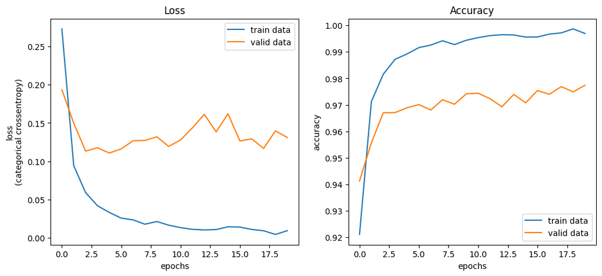

```python
epochs = log_df["epoch"].values
train_acc = log_df["accuracy"].values
train_loss = log_df["loss"].values
valid_acc = log_df["val_accuracy"].values
valid_loss = log_df["val_loss"].values

fig, axes = plt.subplots(1,2, figsize=(12,5))

axes[0].plot(epochs, train_loss, label="train data")
axes[0].plot(epochs, valid_loss, label="valid data")
axes[0].set_xlabel("epochs")
axes[0].set_ylabel("loss\n(categorical crossentropy)")
axes[0].legend(loc="upper right")
axes[0].set_title("Loss")

axes[1].plot(epochs, train_acc, label="train data")
axes[1].plot(epochs, valid_acc, label="valid data")
axes[1].set_xlabel("epochs")
axes[1].set_ylabel("accuracy")
axes[1].legend(loc="lower right")
axes[1].set_title("Accuracy")

plt.show()
```

#### Visualize some inference results

```
1/1 ━━━━━━━━━━━━━━━━━━━━ 0s 50ms/step
```

|  | 0 | 1 | 2 | 3 | 4 | 5 | 6 | 7 | 8 | 9 |
| --- | --- | --- | --- | --- | --- | --- | --- | --- | --- | --- |
| y_test_pred (i=0) | 1.2223e-14 | 7.4586e-12 | 9.3675e-13 | 3.6279e-11 | 2.4061e-15 | 2.4124e-14 | 3.1056e-18 | 1.0 | 3.3854e-13 | 4.2926e-08 |

```
Label with the highest predicted probability (i=0):  7

y_test_true (i=0):  7
x_test (i=0):
```

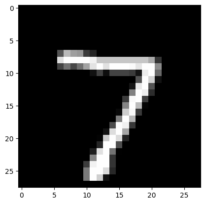

```
-------------------------------------------------------------

1/1 ━━━━━━━━━━━━━━━━━━━━ 0s 58ms/step
```

|  | 0 | 1 | 2 | 3 | 4 | 5 | 6 | 7 | 8 | 9 |
| --- | --- | --- | --- | --- | --- | --- | --- | --- | --- | --- |
| y_test_pred (i=1) | 1.0256e-12 | 3.4976e-10 | 1.0 | 2.6620e-11 | 4.9955e-19 | 5.8833e-17 | 3.9093e-15 | 2.2488e-11 | 1.1078e-10 | 1.8077e-17 |

```
Label with the highest predicted probability (i=1):  2

y_test_true (i=1):  2
x_test (i=1):
```

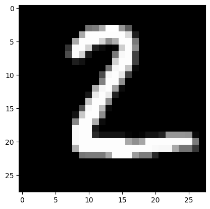

```
-------------------------------------------------------------

1/1 ━━━━━━━━━━━━━━━━━━━━ 0s 45ms/step
```

|  | 0 | 1 | 2 | 3 | 4 | 5 | 6 | 7 | 8 | 9 |
| --- | --- | --- | --- | --- | --- | --- | --- | --- | --- | --- |
| y_test_pred (i=2) | 2.3909e-09 | 1.0 | 3.9373e-08 | 1.1923e-11 | 4.0812e-08 | 2.7246e-10 | 4.6482e-09 | 1.5416e-06 | 9.8937e-07 | 1.5800e-08 |

```
Label with the highest predicted probability (i=2):  1

y_test_true (i=2):  1
x_test (i=2):
```

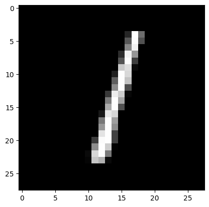

```python
# Visualize the first 3 samples in the test data.
for i in [0, 1, 2]:
    y_true = y_test[i]
    y_pred = model.predict(x_test[i].reshape(1, 28, 28))[0]

    display(pd.DataFrame(columns=range(10), index=[f'y_test_pred (i={str(i)})'], data=[y_pred.tolist()]))
    print("Label with the highest predicted probability", "(i=" + str(i) + "): ", tf.math.argmax(y_pred).numpy(), "\n")

    print("y_test_true", "(i=" + str(i) + "): ", y_true)
    print("x_test", "(i=" + str(i) + "): ")
    plt.imshow(x_test[i], cmap='gray')
    plt.show()
    print("-------------------------------------------------------------\n")
```

```python
# Output the indices of test samples where the prediction and the true label are different.
y_pred = np.argmax(model.predict(x_test), axis=-1)
display(np.where(y_pred != y_test))
```

```
313/313 ━━━━━━━━━━━━━━━━━━━━ 1s 2ms/step
```

```
(array([ 158,  247,  321,  445,  449,  495,  578,  582,  619,  674,  684,
         691,  720,  760,  877,  947,  951, 1014, 1039, 1112, 1156, 1178,
        1181, 1182, 1194, 1226, 1242, 1247, 1270, 1299, 1319, 1328, 1378,
        1395, 1494, 1500, 1522, 1527, 1530, 1549, 1609, 1611, 1681, 1716,
        1722, 1737, 1782, 1880, 1901, 1987, 2035, 2070, 2105, 2109, 2118,
        2125, 2130, 2135, 2182, 2272, 2298, 2369, 2387, 2408, 2437, 2447,
        2462, 2488, 2560, 2597, 2607, 2648, 2654, 2863, 2921, 2927, 2939,
        2953, 2970, 3030, 3073, 3115, 3117, 3225, 3289, 3375, 3405, 3451,
        3475, 3503, 3520, 3558, 3567, 3662, 3681, 3718, 3726, 3727, 3780,
        3808, 3818, 3838, 3853, 3893, 3906, 3941, 3946, 3951, 4065, 4154,
        4176, 4199, 4201, 4224, 4248, 4259, 4289, 4300, 4360, 4415, 4497,
        4536, 4551, 4601, 4731, 4740, 4751, 4807, 4814, 4880, 4886, 4966,
        4997, 5140, 5331, 5457, 5600, 5623, 5634, 5642, 5654, 5676, 5936,
        5937, 5955, 5973, 5997, 6009, 6011, 6421, 6511, 6555, 6574, 6576,
        6597, 6599, 6641, 6651, 6755, 6783, 6847, 6945, 7233, 7370, 7434,
        7841, 8094, 8106, 8110, 8183, 8246, 8279, 8290, 8293, 8325, 8339,
        8408, 8508, 8527, 9009, 9015, 9024, 9587, 9634, 9664, 9669, 9719,
        9729, 9742, 9745, 9764, 9768, 9770, 9779, 9792, 9808, 9839, 9904,
        9922, 9944]),)
```

```
1/1 ━━━━━━━━━━━━━━━━━━━━ 0s 44ms/step
1/1 ━━━━━━━━━━━━━━━━━━━━ 0s 46ms/step
1/1 ━━━━━━━━━━━━━━━━━━━━ 0s 46ms/step
1/1 ━━━━━━━━━━━━━━━━━━━━ 0s 43ms/step
1/1 ━━━━━━━━━━━━━━━━━━━━ 0s 45ms/step
1/1 ━━━━━━━━━━━━━━━━━━━━ 0s 44ms/step
1/1 ━━━━━━━━━━━━━━━━━━━━ 0s 45ms/step
1/1 ━━━━━━━━━━━━━━━━━━━━ 0s 44ms/step
1/1 ━━━━━━━━━━━━━━━━━━━━ 0s 45ms/step
1/1 ━━━━━━━━━━━━━━━━━━━━ 0s 54ms/step
1/1 ━━━━━━━━━━━━━━━━━━━━ 0s 46ms/step
1/1 ━━━━━━━━━━━━━━━━━━━━ 0s 49ms/step
1/1 ━━━━━━━━━━━━━━━━━━━━ 0s 46ms/step
1/1 ━━━━━━━━━━━━━━━━━━━━ 0s 45ms/step
1/1 ━━━━━━━━━━━━━━━━━━━━ 0s 48ms/step
1/1 ━━━━━━━━━━━━━━━━━━━━ 0s 49ms/step
1/1 ━━━━━━━━━━━━━━━━━━━━ 0s 48ms/step
1/1 ━━━━━━━━━━━━━━━━━━━━ 0s 47ms/step
1/1 ━━━━━━━━━━━━━━━━━━━━ 0s 43ms/step
1/1 ━━━━━━━━━━━━━━━━━━━━ 0s 44ms/step
```

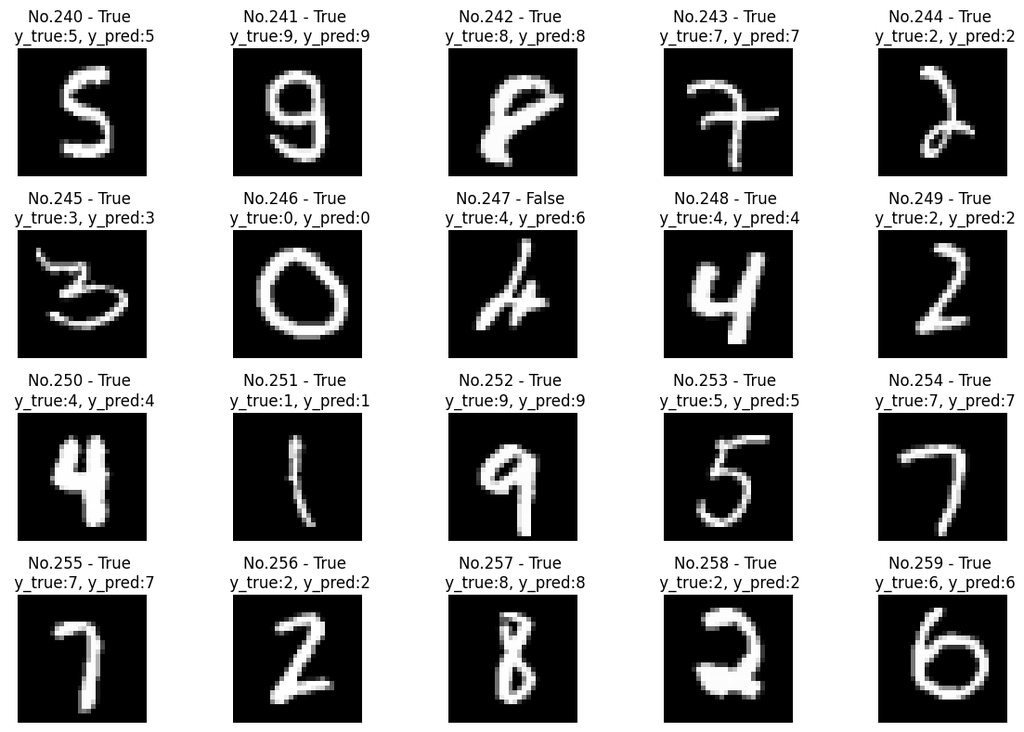

```python
# Visualize the inference results for 20 test samples starting from start_index.

fig = plt.figure(figsize=(12, 8))

ROW = 4
COLUMN = 5
start_index = 240

for i in range(start_index, start_index + ROW * COLUMN):
    y_true = y_test[i]
    y_pred = tf.math.argmax(model.predict(x_test[i].reshape(1, 28, 28))[0])

    if y_true == y_pred:
        result = "True"
    else:
        result = "False"

    plt.subplot(ROW, COLUMN, (i - start_index) + 1)
    plt.imshow(x_test[i], cmap='gray')
    plt.title("No.{} - {} \n y_true:{}, y_pred:{}".format(i, result, y_true, y_pred))
    plt.axis("off")

fig.tight_layout()
fig.show()
```

#### Draw a confusion matrix

Let us check the results using a confusion matrix. A confusion matrix looks like the table below.

| ↓ True label / Predicted label → | 0 | 1 | 2 | 3 | ... |
| --- | --- | --- | --- | --- | --- |
| 0 | Correctly predicted as 0 | Predicted as 1 even though it is 0 | Predicted as 2 even though it is 0 | Predicted as 3 even though it is 0 | ... |
| 1 | Predicted as 0 even though it is 1 | Correctly predicted as 1 | Predicted as 2 even though it is 1 | Predicted as 3 even though it is 1 | ... |
| 2 | Predicted as 0 even though it is 2 | Predicted as 1 even though it is 2 | Correctly predicted as 2 | Predicted as 3 even though it is 2 | ... |
| 3 | Predicted as 0 even though it is 3 | Predicted as 1 even though it is 3 | Predicted as 2 even though it is 3 | Correctly predicted as 3 | ... |
| ... | ... | ... | ... | ... | ... |

The diagonal cells represent correct answers, such as "Correctly predicted as 0", "Correctly predicted as 1", and so on.

```
313/313 ━━━━━━━━━━━━━━━━━━━━ 1s 2ms/step
```

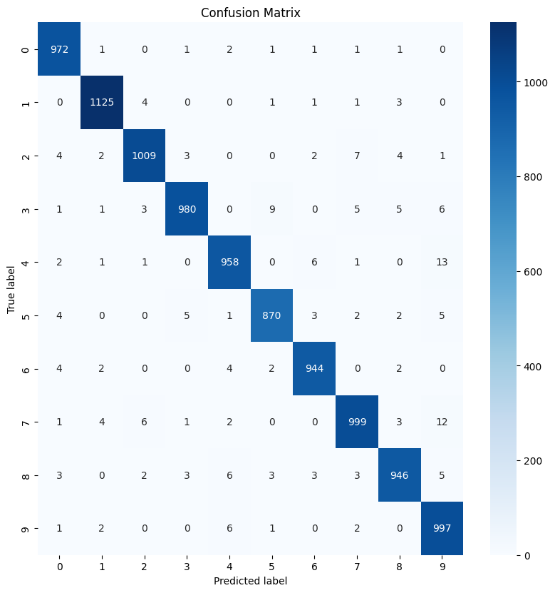

```python
y_pred = np.argmax(model.predict(x_test), axis = -1)
con_matrix = tf.math.confusion_matrix(labels=y_test, predictions=y_pred).numpy()

con_mat_df = pd.DataFrame(con_matrix,
                     index = list(range(10)),
                     columns = list(range(10))
                     )

figure = plt.figure(figsize=(8, 8))
sns.heatmap(con_mat_df, annot=True, cmap=plt.cm.Blues, fmt='g')
plt.tight_layout()
plt.title('Confusion Matrix')
plt.ylabel('True label')
plt.xlabel('Predicted label')
plt.show()
```

### Class distribution of the test dataset

```python
display(pd.Series(y_test, name="Number of test samples (descending order)").value_counts(sort=True).to_frame().T)
```

| Number of test samples (descending order) | 1 | 2 | 7 | 3 | 9 | 4 | 0 | 8 | 6 | 5 |
| --- | --- | --- | --- | --- | --- | --- | --- | --- | --- | --- |
| count | 1135 | 1032 | 1028 | 1010 | 1009 | 982 | 980 | 974 | 958 | 892 |

```python
# Compare ground-truth labels with predictions on the test set (F1-score)
print( classification_report( y_true = y_test, y_pred = y_pred ) )
```

```
              precision    recall  f1-score   support

           0       0.98      0.99      0.99       980
           1       0.99      0.99      0.99      1135
           2       0.98      0.98      0.98      1032
           3       0.99      0.97      0.98      1010
           4       0.98      0.98      0.98       982
           5       0.98      0.98      0.98       892
           6       0.98      0.99      0.98       958
           7       0.98      0.97      0.98      1028
           8       0.98      0.97      0.98       974
           9       0.96      0.99      0.97      1009

    accuracy                           0.98     10000
   macro avg       0.98      0.98      0.98     10000
weighted avg       0.98      0.98      0.98     10000
```

### Appendix: Visualization with TensorBoard

When you run this code, allow third-party cookies in the browser where Colab is open. If they are blocked, you may get a 403 error.

```python
%tensorboard --logdir logs/fit
```